# Data Science With an Eye Towards Sustainability A12: Evaluating Statistical Models

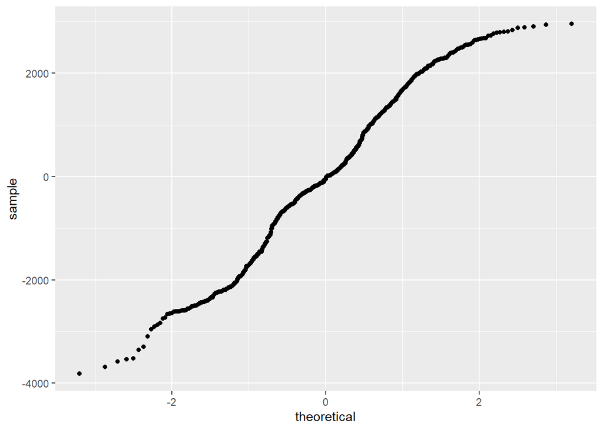

```r
ggplot(datE, aes(sample=residuals))+
  geom_qq()
```

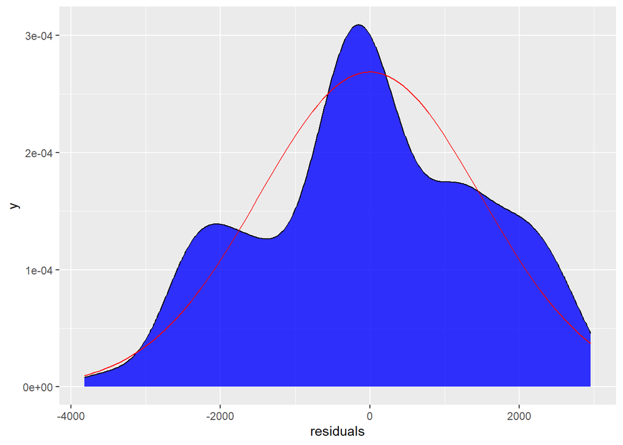

```r
ggplot(datE, aes(x=residuals)) +
  geom_density(fill="blue",alpha=.8)+
  stat_function(fun = dnorm, n = 101, args = list(mean = 0, sd = sd(datE$residuals)),color="red")
```

::: {.solution} Part e Assumptions - Independence: Unmet? Days are tied together by confounding variables, but two random Mondays should’t have an impact on two random Thursdays? - Expected value of residuals: Met? This is a weird one, but it seems balanced around the y=0 line. - Homoskedasticity: Met?? Again, weird one, but no banana or coning. - Normality of residuals: Unmet, does not seem normal. :::

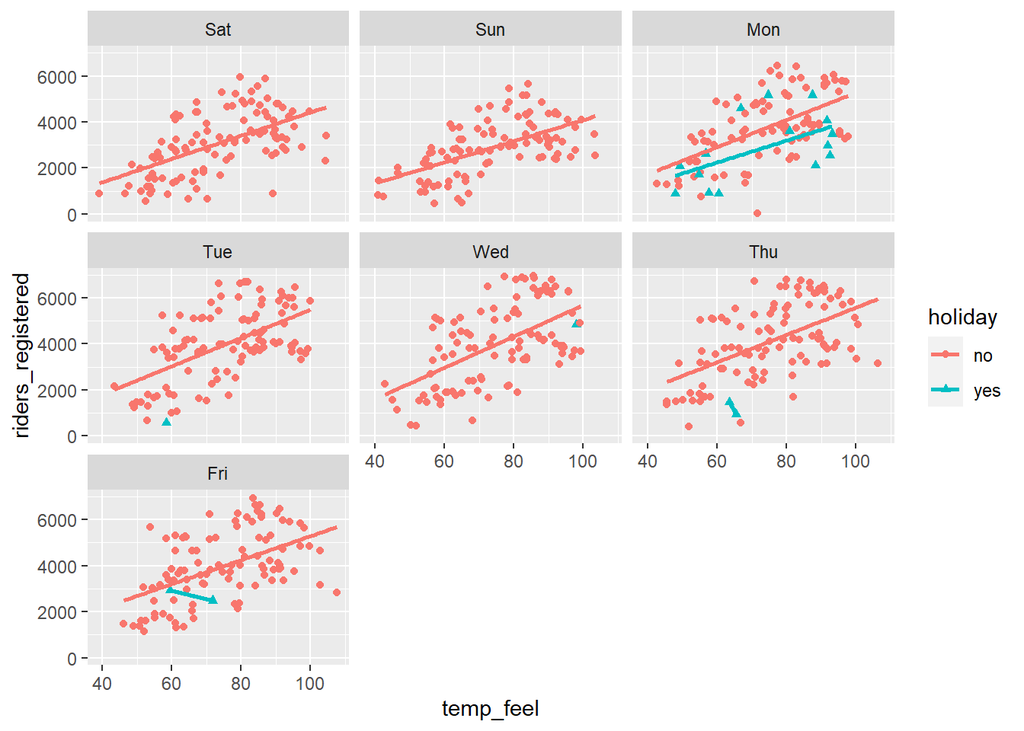

```r
ggplot(bikes, aes(x=temp_feel, y=riders_registered, color=holiday, shape=holiday))+
  geom_point()+
  facet_wrap(~day_of_week)+
  geom_smooth(method='lm',se=FALSE)
```

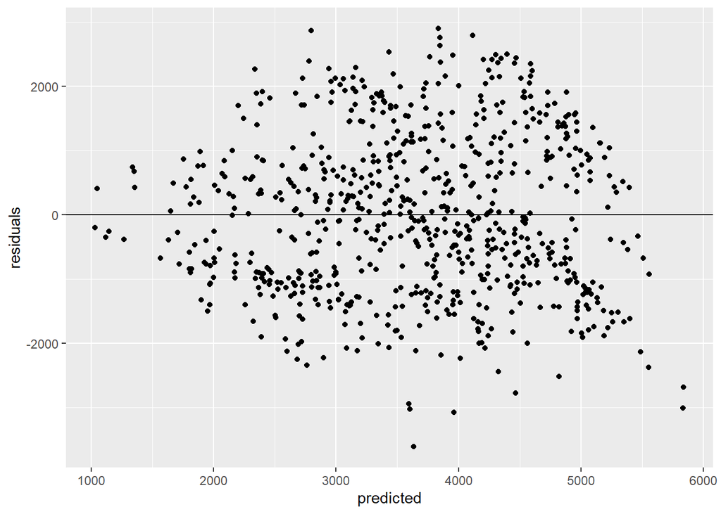

```r
modF = lm(riders_registered ~ day_of_week + holiday + temp_feel, data=bikes)

datF <- data.frame(
  residuals=modF$residuals,
  predicted=modF$fitted.values)

ggplot(datF, aes(x=predicted, y=residuals))+
  geom_point()+
  geom_hline(yintercept=0)
```

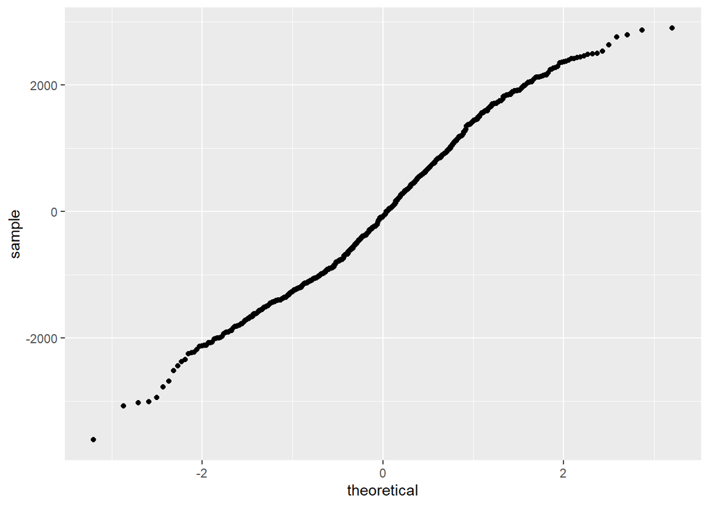

```r
ggplot(datF, aes(sample=residuals))+
  geom_qq()
```

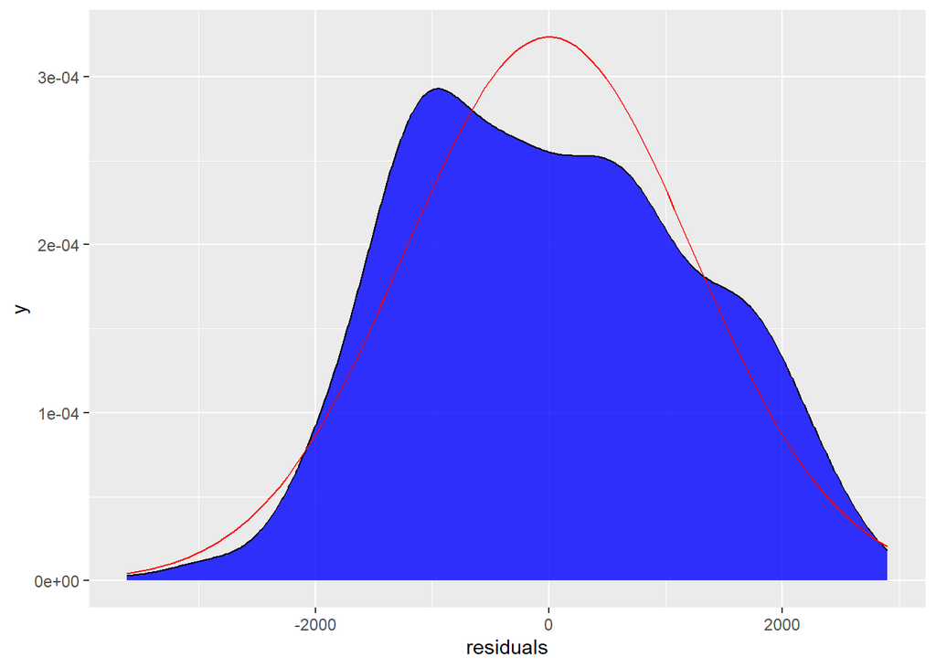

```r
ggplot(datF, aes(x=residuals)) +
  geom_density(fill="blue",alpha=.8)+
  stat_function(fun = dnorm, n = 101, args = list(mean = 0, sd = sd(datF$residuals)),color="red")
```

::: {.solution} Part f Assumptions - Independence: Unmet. The temperature from one day to the next is not independent. We expect similar temperatures from one day to the next. - Expected value of residuals: Met, seems balanced around y=0 - Homoskedasticity: Unmet. Double cone shape (football shape?) happening. - Normality of residuals: Met? Looks pretty normal? :::

**Exercise 4.2** In this exercise, you’ll explore the relationship between a (quantitative) response variable of your choosing and a (quantitative or categorical) explanatory variable of your choosing. Choose a pair that hasn’t yet been investigated in this activity.

1. Make a plot showing the relationship between the two variables you chose.
2. In understanding the relationship between these variables, what other variables might you want to control for (i.e., include as covariates)?
3. Build a model with your identified response variable and explanatory variable (initial choice and covariates).
4. What portion of the variation in the response variable is explained by your model?
5. How well are the assumptions of linear regression satisfied for your model?

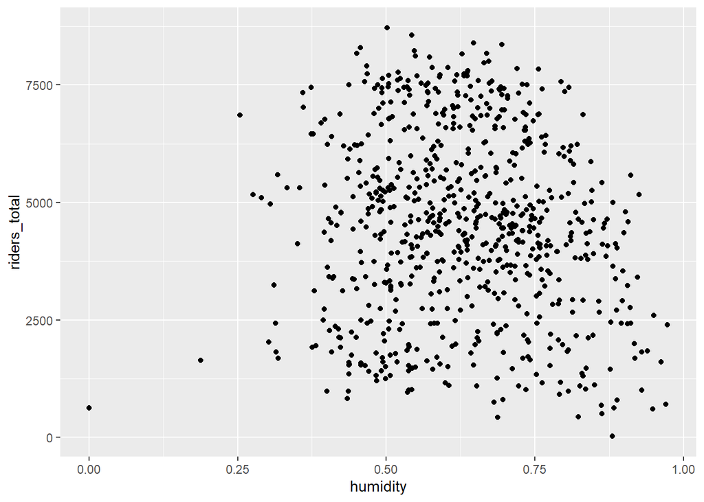

```r
ggplot(bikes, aes(x=humidity, y=riders_total))+
  geom_point()
```

```r
modG <- lm(riders_total ~ 1 + humidity + temp_feel, data=bikes)
summary(modG)
```

```
##
## Call:
## lm(formula = riders_total ~ 1 + humidity + temp_feel, data = bikes)
##
## Residuals:
##     Min      1Q  Median      3Q     Max
## -4833.9 -1071.8   -54.8  1050.2  4308.5
##
## Coefficients:
##              Estimate Std. Error t value Pr(>|t|)
## (Intercept)  -341.384    345.088  -0.989    0.323
## humidity    -2622.019    382.788  -6.850 1.57e-11 ***
## temp_feel      86.918      3.717  23.382  < 2e-16 ***
## ---
## Signif. codes:  0 '***' 0.001 '**' 0.01 '*' 0.05 '.' 0.1 ' ' 1
##
## Residual standard error: 1459 on 728 degrees of freedom
## Multiple R-squared:  0.4347, Adjusted R-squared:  0.4331
## F-statistic: 279.9 on 2 and 728 DF,  p-value: < 2.2e-16
```

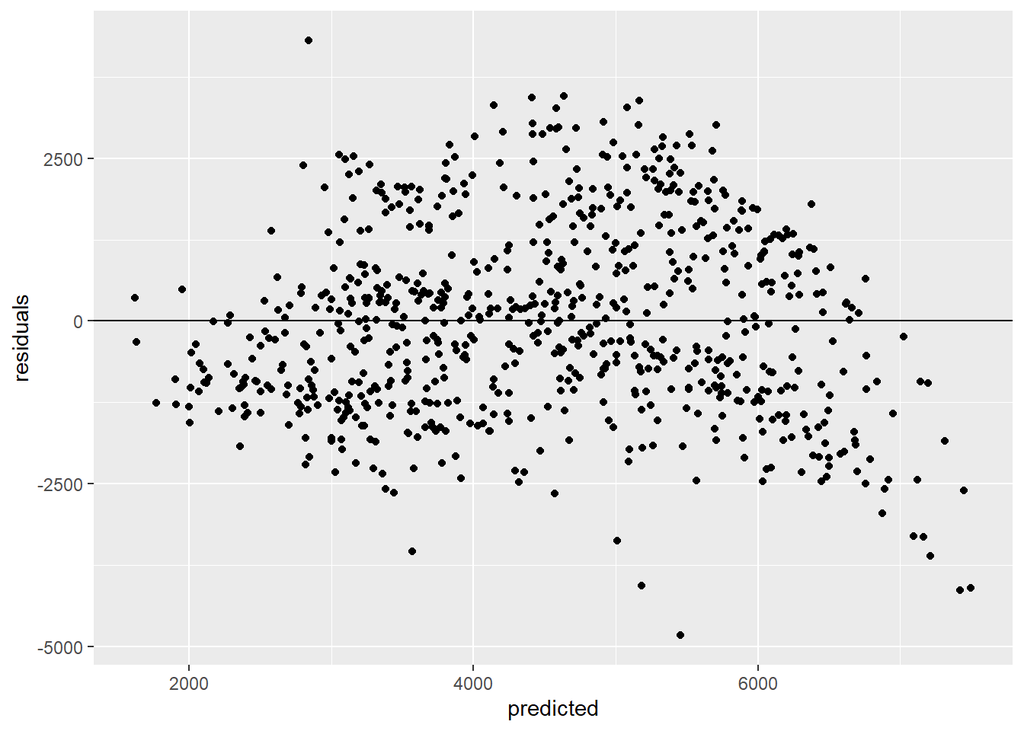

```r
datG <- data.frame(
  residuals=modG$residuals,
  predicted=modG$fitted.values)

ggplot(datG, aes(x=predicted, y=residuals))+
  geom_point()+
  geom_hline(yintercept=0)
```

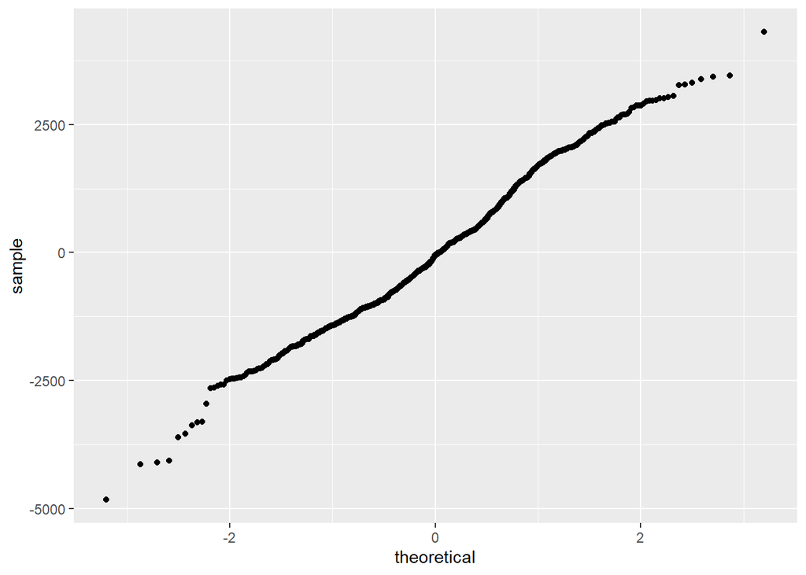

```r
ggplot(datG, aes(sample=residuals))+
  geom_qq()
```

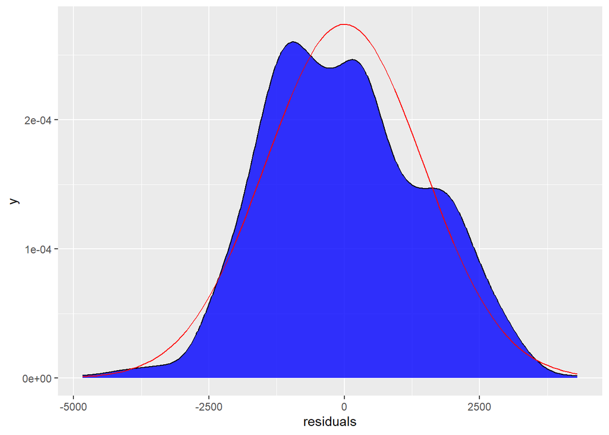

```r
ggplot(datG, aes(x=residuals)) +
  geom_density(fill="blue",alpha=.8)+
  stat_function(fun = dnorm, n = 101, args = list(mean = 0, sd = sd(datG$residuals)),color="red")
```

*Solution*.

2. the temperature that it feels like
3. 43.5%
- Independance: Unmet, humidiy and temperature are not independant because they are similar day to day
- Expected value of residuals: Met? There seems to be an equal number of points above and below, but it’s hard to tell due to the curve
- Homoskedasticity: Unmet. Very banana shaped.
- Normality of residuals: Met? Pretty normal looking.